# Perfil Musical a partir de dados da base Last.Fm

Lucas Xavier

2021-11-27

# Objetivo

Este é um relatório elaborado como projeto final do curso ‘R para Ciência de Dados I’, da curso-r. Neste relatório eu busco levantar e analisar dados pessoais referentes a histórico de músicas documentadas na plataforma “Last.fm”, com o objetivo de traçar o meu perfil musical principalmente no período de 2020/2021.

Serão avaliadas informações como artistas, álbuns e músicas mais escutadas, bem como, a quantidade de vezes que cada um desses foi escutado, estabelecendo-se um perfil de preferência/gosto musical.

# Contextualização

A base de dados utilizada é referente ao portal Last.fm, esse é um site com função de rádio online que visa gerar uma comunidade centrada e fundada com base em música. O site foi fundado em 2002, no Reino Unido, e atualmente representa uma das principais plataformas sociais voltadas para música na internet com um contingente de usuários que datam de mais de 40 milhões no mundo e com uma contagem de scrobbles que totalizam mais de 96 bilhões desde 2003 (showmetech, 2021).

Uma das ferramentas disponibilizadas pela plataforma e que gera um atrativo entre os usuários são as contagens de “streams”, ou, basicamente, o número de vezes que você escuta uma faixa de música. A partir desses dados o próprio site realiza estudos estatísticos que permitem avaliar seus artistas, faixas e álbuns mais escutados em diferentes períodos de tempo.

A base de dados para o relatório foi extraída do próprio site através do meu nome de usuário por meio do portal (https://mainstream.ghan.nl/export.html) que permite exportar o seu histórico de músicas em “.csv” ou outros formatos.

# Banco de Dados

O Banco de dados utilizado apresenta informações referentes ao período de dezembro de 2019 até outubro de 2021. A seguir é apresentado uma amostra dos dados mais recentes, primeiras 30 linhas do total de 31.439 linhas, a fim de se entender a sua construção e disposição dos dados.

| dia | mes | ano | artista | album | musica |
| --- | --- | --- | --- | --- | --- |
| 31 | Oct | 2021 | ENHYPEN | DIMENSION : DILEMMA | Blockbuster feat. YEONJUN of TOMORROW X TOGETHER |
| 31 | Oct | 2021 | ENHYPEN | DIMENSION : DILEMMA | Attention, please! |
| 31 | Oct | 2021 | ENHYPEN | DIMENSION : DILEMMA | Just A Little Bit |
| 31 | Oct | 2021 | ENHYPEN | DIMENSION : DILEMMA | Upper Side Dreaminâ€™ |
| 31 | Oct | 2021 | ENHYPEN | DIMENSION : DILEMMA | Go Big or Go Home |
| 31 | Oct | 2021 | ENHYPEN | DIMENSION : DILEMMA | Interlude : Question |
| 31 | Oct | 2021 | ENHYPEN | DIMENSION : DILEMMA | Tamed-Dashed |
| 31 | Oct | 2021 | NCT 127 | Favorite - The 3rd Album Repackage | Favorite (Vampire) |
| 31 | Oct | 2021 | ENHYPEN | DIMENSION : DILEMMA | Intro : Whiteout |
| 31 | Oct | 2021 | THE ANXIETY | THE ANXIETY | Meet Me At Our Spot |

[output cut: 20 more lines]

As principais variáveis disponíveis na base de dados são as seguintes:

```
## [1] "dia"     "mes"     "ano"     "artista" "album"   "musica"
```

## Caracterização do Banco de Dados

Realizando-se uma caracterização da base de dados, avalia-se que ao todo tem-se avaliados 1045 artistas e um total de 31439 streams, como apresentado na tabela abaixo. Apresenta-se também o nome de todos os artistas presentes a seguir.

| Artistas | Stream |
| --- | --- |
| 1045 | 31439 |

| Artistas |
| --- |
| ENHYPEN |
| NCT 127 |
| THE ANXIETY |
| Alex Turner |
| Catfish and the Bottlemen |
| The Vaccines |
| Jake Bugg |
| The Last Shadow Puppets |
| The Fratellis |
| Sundara Karma |

[output cut: 1035 more lines]

# Análise dos dados

## Análise dados totais

### Artistas mais escutados

Primeiramente, a fim de avaliar os artistas que mais escutei ao longo de toda a série analisada elaborei um ranking em função da quantidade de vezes que cada artista teve sua música por mim reproduzida. Para tanto, em função da extensão do banco de dados, busquei limitar a análise aos 10 artistas mais escutados, seguido da quantidade de vezes que eles foram escutados.

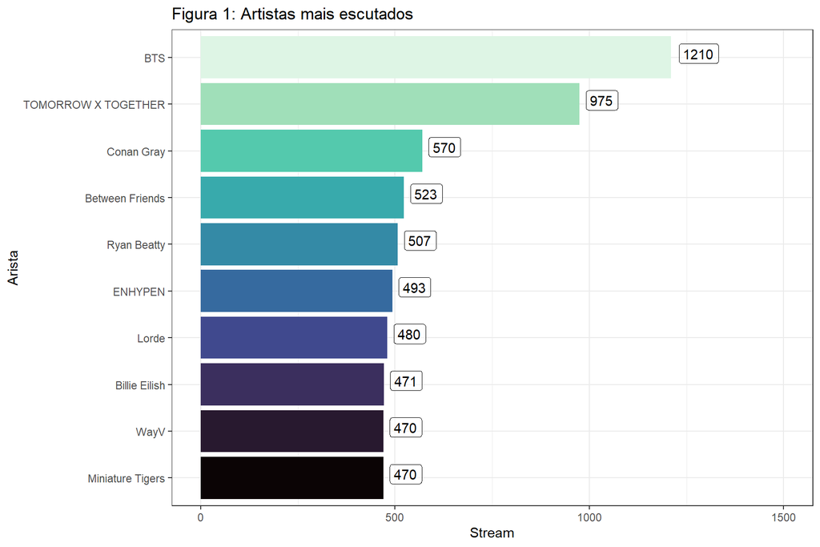

Dos artistas apresentados no gráfico acima, o grupo BTS representa o artista mais escutado. É interessante observar que, exceto pelos dois primeiros artistas, todos os outros possuem valores de streams bem próximos uns dos outros, quando não iguais. Porém, a partir do terceiro artista (Conan Gray) avalia-se uma diferença de 405 streams para o segundo (Tomorrow X Together) e de 640 streams para o primeiro (BTS).

### Albuns mais escutados

Através da base também se faz possível a avaliação dos álbuns mais escutados, apresentados abaixo:

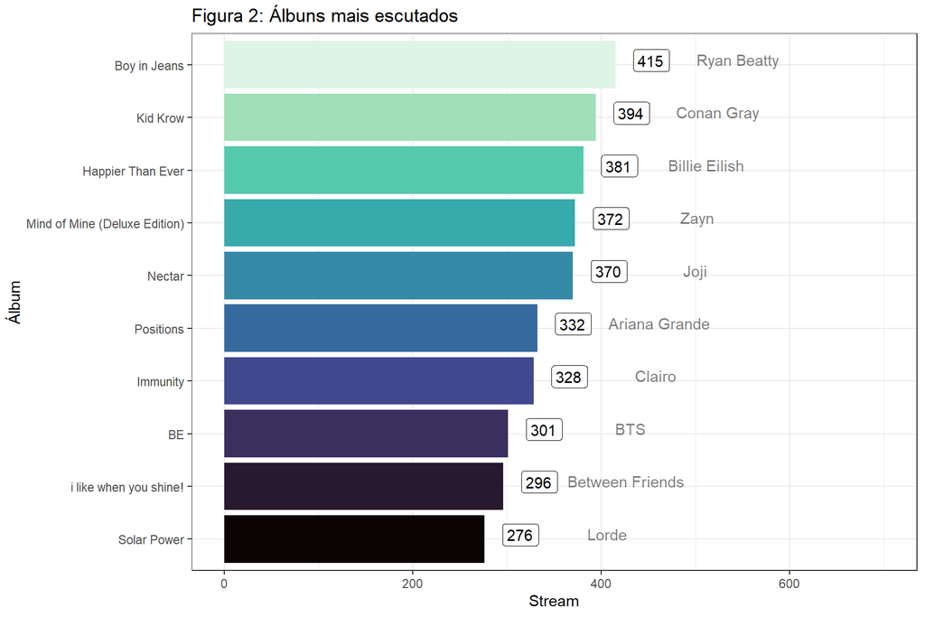

### Músicas mais escutadas

Outra análise interessante de ser realizada diz respeito a avaliação das músicas mais escutadas na série analisada.

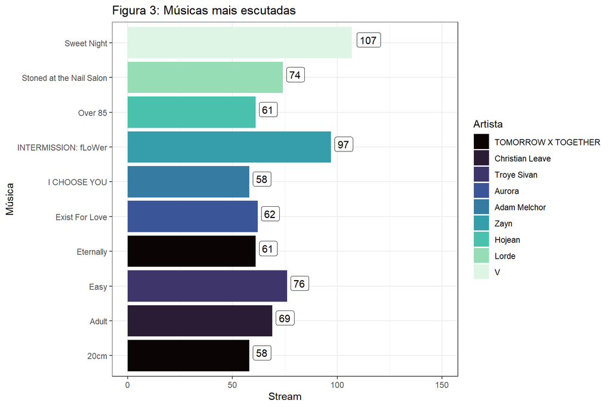

Tem-se como música mais escutada Sweet Night (V/Taehyung), seguida por Intermission:Flower (Zayn Malik) e Easy (Troye Sivan).

## Análises Filtradas

Tendo-se analisado os dados considerando sua totalidade, agora realiza-se uma análise adotando os anos da série enquanto um critério de agrupamento, a fim de que se possa avaliar também os artistas, álbuns e músicas mais escutados por ano de abrangência. Tais resultados e análises são apresentados a seguir.

### Streams por ano da série histórica

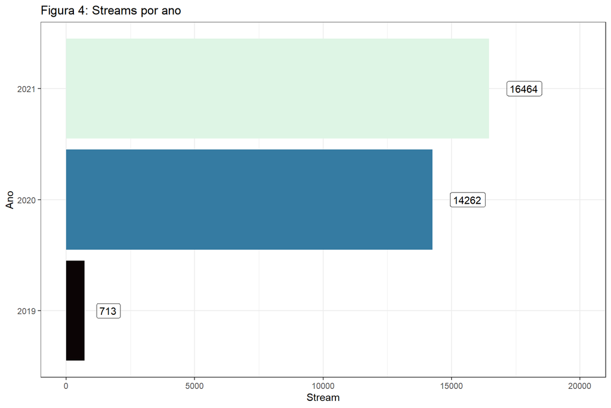

Primeiramente, se avaliou a quantidade de streams por ano da série. A partir do gráfico acima observa-se que a maior quantidade de streams ocorreu no ano de 2021 (até o mês de outubro). Deve-se ressaltar que a grande variação nos resultados está associado ao período de abrangência dos dados de cada ano.

### Músicas mais escutadas por ano da série histórica

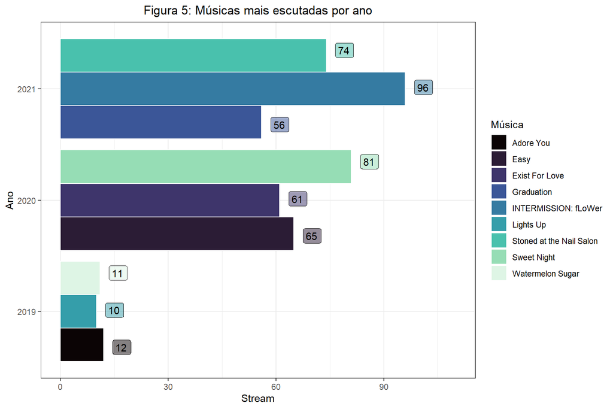

### Artistas mais escutados por ano da série histórica

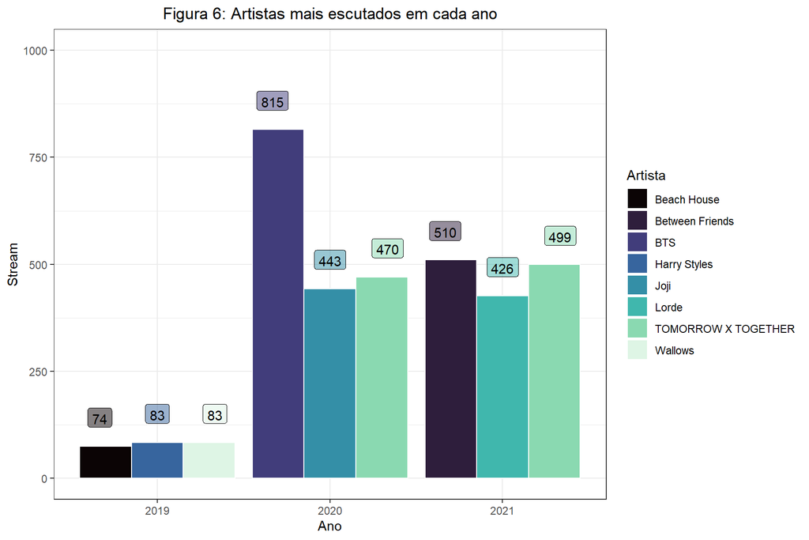

A análise a respeito dos artistas mais escutados permitiu avaliar que meus artistas mais escutados por ano, respectivamente, foram Harry Styles, BTS e Between Friends. Observa-se que a maior quantidade de streams esteve associada ao ano de 2020 e que no anos de 2020 e 2021 o grupo musical Tomorrow x Together ocupou duas vezes a segunda posição.

### Álbuns mais escutados por ano da série histórica

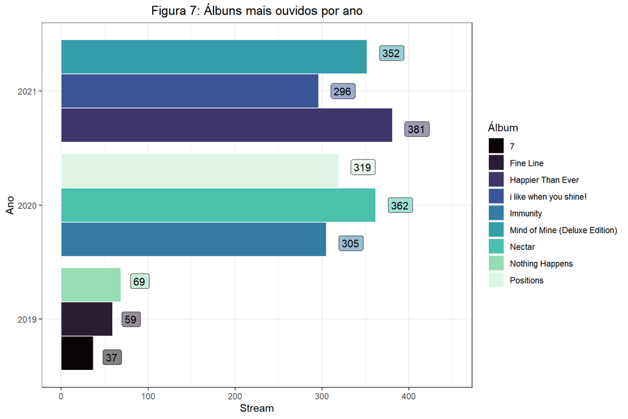

Acerca dos álbuns mais escutados, tem-se que ocuparam por ano, respectivamente, a posição principal os álbuns “Nothing Happens” (Wallows), “Nectar” (Joji) e “Happier Than Ever” (Billie Eilish). Assim como para o caso das músicas mais escutadas, observa-se para o ano de 2021 uma maior quantidade de streams no álbum mais ouvido, mesmo antes do final do ano.

# Perfil Musical e Conclusão

Os dados levantados a respeito da dinâmica de consumo de música nos últimos anos, além de avaliar os artistas, álbuns e músicas preferidos, e, portanto, mais escutados, permitem observar essa distribuição ao longo dos anos e com a respectiva frequência de reprodução. Dessa forma, se faz possível traçar um perfil musical que perpassa minhas preferências neste âmbito.

Trazendo uma breve retrospectiva dos resultados obtidos, tive, quando considerado todos os dados da base, que meu artista, álbum e música mais escutados foram respectivamente BTS, Boy in Jeans e Sweet Night. Com relação aos artistas, pode-se avaliar uma distribuição de “streams” com maior variação dos primeiros colocados para com os restantes, do que para as outras análises. Dessa forma, pode-se inferir que possuo padrões de streams que variam entre as categorias, além disso, uma vez que a contagem por artista implica na contagem de toda e qualquer música reproduzida que pertença à este, avalia-se que para os primeiros tem-se um comportamento de consumo que independe do álbum, mas que se estende por toda a discografia do artista.

Já a respeito das análises filtradas por ano, observa-se que minha maior totalidade de streams ocorreu no ano de 2021¹ e cuja distribuição de artistas, álbuns e músicas mais escutados foi bem variada, com apenas um artista (Tomorrow x Together) repetindo em dois dos anos. Ademais, apesar de não informada nas bases, os artistas principais apresentados caracterizam gêneros musicais pertencentes ao Pop, Folk, Indie Rock, Kpop e Indie Pop.

De forma geral, traça-se o perfil de uma pessoa que disponibiliza grande parte de suas horas diárias para escutar músicas, com artistas variados, mas cuja preferência é bem definida, principalmente com relação aos álbuns e músicas mais escutadas. A seguir, apresenta-se os respectivos artista, álbum e música com maior quantidade de reprodução.

¹ Considerando se ter dados referentes à apenas um mês do ano de 2019

Artista mais escutado: **BTS**

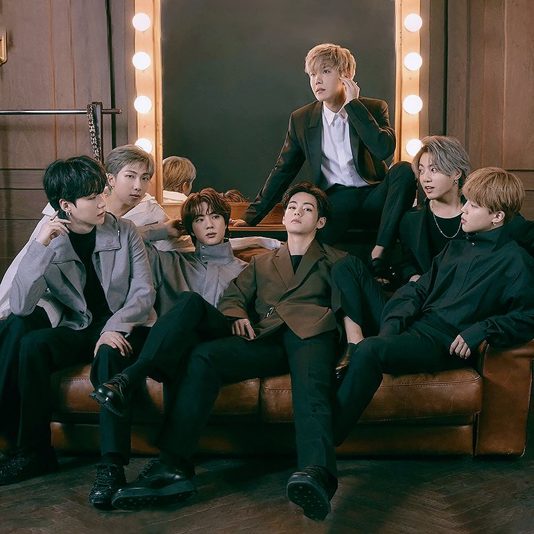

Álbum mais escutado: **Boy in Jeans**

[figure not shown]

Música mais escutada: **Sweet Night**

[figure not shown]

# Referências

- [Portal ShowmeTech](https://www.showmetech.com.br/last-fm-como-usar/)
- [Material do curso ‘R para Ciência de Dados I’](https://curso-r.github.io/main-r4ds-1/)